# R Markdown Primer

Tobias Lochner

2025-11-16

# Introduction

R Markdown is a framework that allows for the creation of documents such as PDFs and htmls. Within these documents users can blend text with executable R code.

# Narrative

Doing this assignment has shown the benefits of being able to use R Markdown. Not only can we easily run and execute R code just like we can with an R script, we can also include plain text that allows us to tell a story with our data. Along with this R Markdown allows us to output this document that combines both R code and text in easy to read file formats such as html, pdf, or word.

# LaTeX Expression

The Pythagorean Theorem is $C^2 = A^2 + B^2$

```r
# 1st R Chunk

head(iris)
```

```
##   Sepal.Length Sepal.Width Petal.Length Petal.Width Species
## 1          5.1         3.5          1.4         0.2  setosa
## 2          4.9         3.0          1.4         0.2  setosa
## 3          4.7         3.2          1.3         0.2  setosa
## 4          4.6         3.1          1.5         0.2  setosa
## 5          5.0         3.6          1.4         0.2  setosa
## 6          5.4         3.9          1.7         0.4  setosa
```

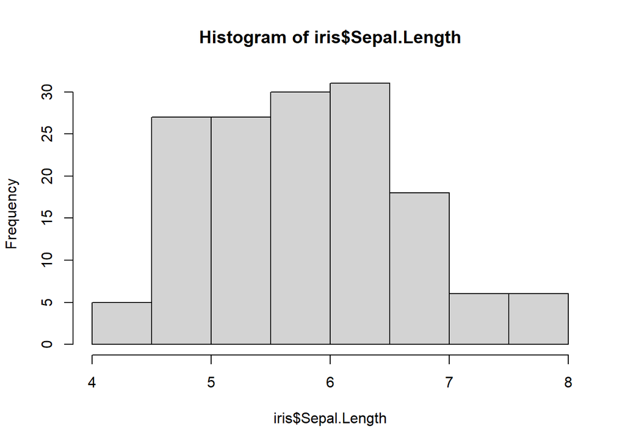

```r
# 2nd R Chunk

hist(iris$Sepal.Length)
```

# Conclusion

I’ve used R Markdown in several classes before this, and it makes creating any sort of report that involves code very easy. I also think it’s quite useful in school since it allows instructors to create Rmd files that include instructions and allow you to input the needed code. Like filling out a worksheet.